# Exploring the BRFSS data

## Setup

### Load packages

```r
library(ggplot2)
library(dplyr)
```

### Load data

```r
load("brfss2013.RData")
```

## Part 1: Data

**The data was specifically chosen for each research question.** **For the first research question, stratified sampling was used as the entire population was grouped into male and female categories and then random sampling was applied to each group to extract 1000 samples for analysis. This piece of sampling probably provides the best generalizability.** **For the question regarding income, education and healt, only the employed portion of the population was selected since this category would be more likely to earn an income. Hence this analysis is generalizable to the population that is employed.** **For the third question, all reported entries were taken into consideration. At the end, the results could be generalizable to each state since the reported disease rates were determined as a percentage for comparison as opposed to the total number of entries from each state.**

**Causality cannot be determined in study since it is an observational study. Since it is not an experimental study, there is no random assignment.**

## Part 2: Research questions

**Research quesion 1: Are men more likely to engage in risk behaviors?**

**– Risk behaviors are some of the most important factors that BRFSS takes into account during their surveys and could be directly or indirectly related health problems, both chronic and acute.**

**Furthermore, understanding the nature of risk behaviors among the male and female populations could help in identifying specific health issues affecting each gender. The behaviors we are interested in are drinking habits and tobacco use.**

**– Variables: Sex (sex), smoked atleast 100 cigarettes (smoke100), frequency of days now smoking (smokday2), interval since last smoked (lastsmk2), use of smokeless tobacco products (usenow3), alcohol in the last 30 days (alcday5), average drinks per day (avedrnk2), 5 or more drinks (drnk3ge5), most drinks on a single occasion (maxdrnks5)**

**Research quesion 2: Among people who are employed, how are education and income level related to their health?**

**– In a country of ever-increasing healthcare costs, only some of the population having access to quality treatment and monitoring. This question is aimed at exploring whether people with better income or education actually have better health care acccess due to their ability to pay more health services. Another relationship to explore would be between income and education. The population selected are people who are employed since we are looking at people who have a source of income.**

**– Variables: Education level (educa), employment status (employ1), income level (income2), general health (genhlth), number of days physical health not good (physhlth), number of days mental health not good (menthlth), poor mental or physical health (poorhlth)**

**Research quesion 3: Which states exhibit the highest and lowest rates of chronic diseases?**

**– With chronic diseases such as stroke, diabetes and cancer being some of the costliest and most prevalent conditions in the US, this question is designed to explore the distribution and characteristics of these diseases across all states in the country with special emphasis on states with the highest and lowest risks.**

**– Variables: States (X_states), ever diagnosed with heart attack (cvdinfr4), ever diagnosed with Angina or CHD (cvdcrhd), ever diagnosed with a stroke (cvdstrk3), ever told had asthma (asthma3), ever told have skin cancer (chcscncr), other types of cancer (chcocncr), ever told have COPD or emphysema (chcopd1), told have arthritis (havarth3), told have depressive disorder (addepev2), told have kidney disease (chckidny), told have diabetes (diabete3)**

## Part 3: Exploratory data analysis

**Research quesion 1: Are men more likely to engage in risk behaviors?**

**Creating a subset of the main dataset ‘brfss2013’ containing just the variables of interest and filtering any n/a values for the ‘sex’ variable since we are only concerned with valid responses**

```r
gensmkdrnk <- brfss2013 %>%
  select(sex,smoke100,smokday2,stopsmk2,lastsmk2,usenow3,alcday5,avedrnk2,drnk3ge5,maxdrnks) %>%
  filter(!(is.na(sex)))
```

**Looking at the total number of male and female responses and providing a bar plot visualization**

```r
gensmkdrnk %>%
  group_by(sex) %>%
  summarise(count=n())
```

```
## # A tibble: 2 x 2
##      sex  count
##   <fctr>  <int>
## 1   Male 201313
## 2 Female 290455
```

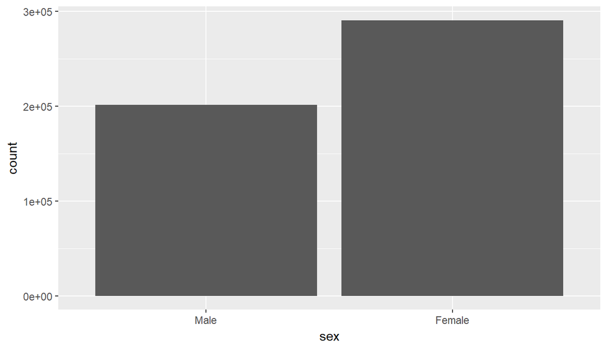

```r
ggplot(data=gensmkdrnk,aes(x=sex))+geom_bar()
```

**Sampling 1000 random observations for male and female. Using stratified sampling in order to get equal and random samples from each gender for a suitable comparison**

```r
male_smoke <- gensmkdrnk %>%
  filter(sex=="Male")
male_sample <- sample_n(male_smoke,1000)

fem_smoke <- gensmkdrnk %>%
  filter(sex=="Female")
fem_sample <- sample_n(fem_smoke,1000)
```

**Combining the 1000 sample observations from the male and female populations to create the final data subset for analysis of risk behavior variables and visualizations. Also making sure that ’genrisk_sample consists of exactly 1000 observations from each gender**

```r
genrisk_sample <- rbind(fem_sample,male_sample)
genrisk_sample %>%
  group_by(sex) %>%
  summarise(count=n())
```

```
## # A tibble: 2 x 2
##      sex count
##   <fctr> <int>
## 1   Male  1000
## 2 Female  1000
```

**Tobacco Use Analysis**

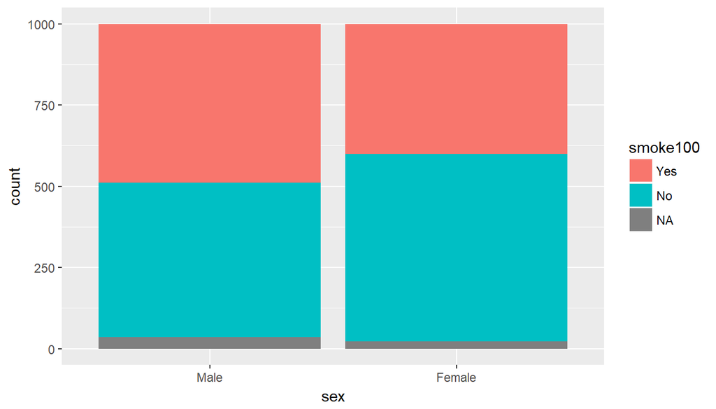

```r
ggplot(data=genrisk_sample,aes(x=sex,fill=smoke100))+geom_bar()
```

**By simply glancing at the plot above, slightly more men in general have smoked at least a 100 cigarettes in their lifetime.** ** **

```r
genrisk_sample%>%
  group_by(sex,smokday2) %>%
  filter(!(is.na(smokday2))) %>%
  summarise(count=n())
```

```
## # A tibble: 6 x 3
## # Groups:   sex [?]
##      sex   smokday2 count
##   <fctr>     <fctr> <int>
## 1   Male  Every day   116
## 2   Male  Some days    52
## 3   Male Not at all   321
## 4 Female  Every day   120
## 5 Female  Some days    40
## 6 Female Not at all   241
```

**If we look at the frequency of smoking, females have a marginally higher tendency to smoke everyday while more men tend to smoke on some days. Although this does not tell us much about how many cigarettes a day is smoked or what the frequency of smoking is for the ‘some days’ case.** ** **

```r
genrisk_sample%>%
  group_by(sex,usenow3) %>%
  filter(!(is.na(usenow3))) %>%
  summarise(count=n())
```

```
## # A tibble: 6 x 3
## # Groups:   sex [?]
##      sex    usenow3 count
##   <fctr>     <fctr> <int>
## 1   Male  Every day    41
## 2   Male  Some days    17
## 3   Male Not at all   909
## 4 Female  Every day     2
## 5 Female  Some days     9
## 6 Female Not at all   965
```

**In the use of smokeless tobacco products, men exhibit a significantly higher numbers. Men who use smokeless tobacco products everyday are 41 to 2 for women whereas the ratio for some days is 17 for men to 9 for women. These stats tell us that there could be a telling difference in tobacco use habits.**

**Alcohol Consumption Analysis**

**The data below represents days of alcohol use per week and per month**

```r
genrisk_sample%>%
  group_by(sex) %>%
  filter(!(is.na(alcday5)),alcday5>99,alcday5<200) %>%
  summarise(n(),mean(alcday5),sd(alcday5),max(alcday5),min(alcday5))
```

```
## # A tibble: 2 x 6
##      sex `n()` `mean(alcday5)` `sd(alcday5)` `max(alcday5)` `min(alcday5)`
##   <fctr> <int>           <dbl>         <dbl>          <dbl>          <dbl>
## 1   Male   154        103.2338      2.076297            107            101
## 2 Female   115        102.6000      1.715768            107            101
```

**On average men seem to drink on more days per week than women according to the data above.**

```r
genrisk_sample%>%
  group_by(sex) %>%
  filter(!(is.na(alcday5)),alcday5>199) %>%
  summarise(n(),mean(alcday5),sd(alcday5),max(alcday5),min(alcday5))
```

```
## # A tibble: 2 x 6
##      sex `n()` `mean(alcday5)` `sd(alcday5)` `max(alcday5)` `min(alcday5)`
##   <fctr> <int>           <dbl>         <dbl>          <dbl>          <dbl>
## 1   Male   414        209.5894      9.880177            230            201
## 2 Female   312        207.5160      9.014087            230            201
```

**Again, men tend to drink on more days per month on average based on the stats presented above.**

**The data below shows the distribution of the average alcohol drinks consumed per day.**

**The right skewed plot below shows that more women tend to drink one drink on average per day. But, the proportion of men starts to increase as the average number of drinks increases.**

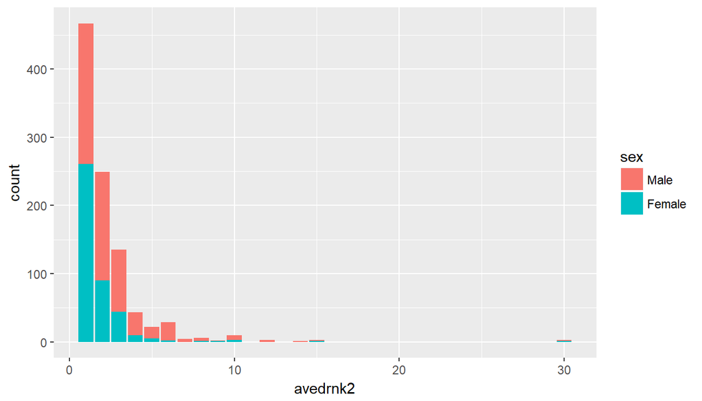

```r
ggplot(data=genrisk_sample,aes(x=avedrnk2,fill=sex))+geom_bar()
```

```r
genrisk_sample %>%
  group_by(avedrnk2,sex) %>%
  filter(avedrnk2<15) %>%
  summarise(count=n())
```

```
## # A tibble: 21 x 3
## # Groups:   avedrnk2 [?]
##    avedrnk2    sex count
##       <int> <fctr> <int>
##  1        1   Male   206
##  2        1 Female   261
##  3        2   Male   159
##  4        2 Female    90
##  5        3   Male    91
##  6        3 Female    44
##  7        4   Male    33
##  8        4 Female    10
##  9        5   Male    17
## 10        5 Female     5
## # ... with 11 more rows
```

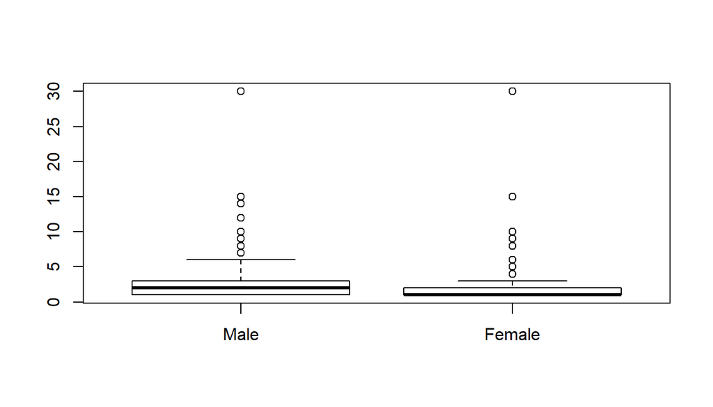

```r
plot(genrisk_sample$sex,genrisk_sample$avedrnk2)
```

**The data from the plot is made a bit clearer with the tabulated data above. Note that 15 drinks per day was chosen as the cutoff point for the data since the plot shows a right skewed distribution and the data becomes less meaningful with number of drinks above 15. There seems to be an outlier at 30 drinks but this point is not important for this analysis.**

**The boxplots above further reflect the analysis with the data showing a relatively higher median and IQR for men.** ** **

**Looking at the plot below, men tend to binge drink (5 or more drinks) on more days than women, especially as the plot skews towards the right.**

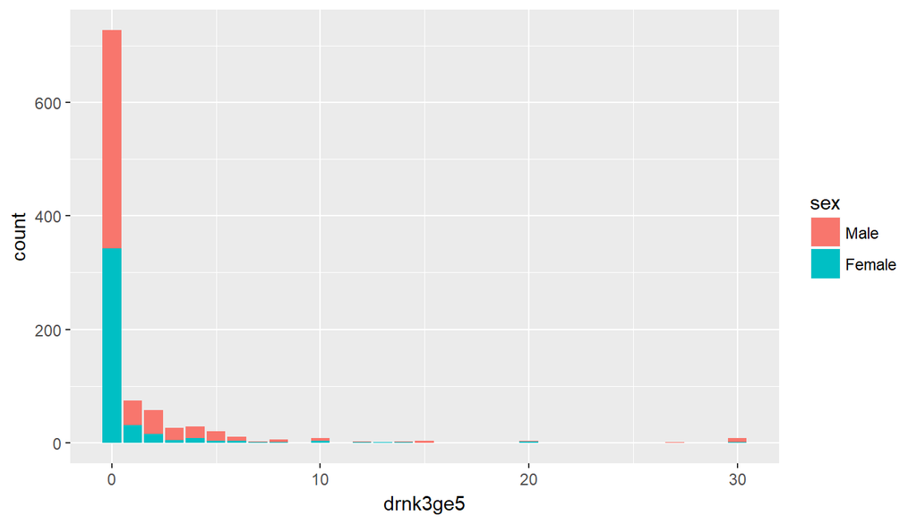

```r
ggplot(data=genrisk_sample,aes(x=drnk3ge5,fill=sex))+geom_bar()
```

```r
genrisk_sample %>%
  group_by(drnk3ge5,sex) %>%
  filter(drnk3ge5<15) %>%
  summarise(count=n())
```

```
## # A tibble: 25 x 3
## # Groups:   drnk3ge5 [?]
##    drnk3ge5    sex count
##       <int> <fctr> <int>
##  1        0   Male   385
##  2        0 Female   342
##  3        1   Male    44
##  4        1 Female    31
##  5        2   Male    41
##  6        2 Female    16
##  7        3   Male    21
##  8        3 Female     5
##  9        4   Male    21
## 10        4 Female     8
## # ... with 15 more rows
```

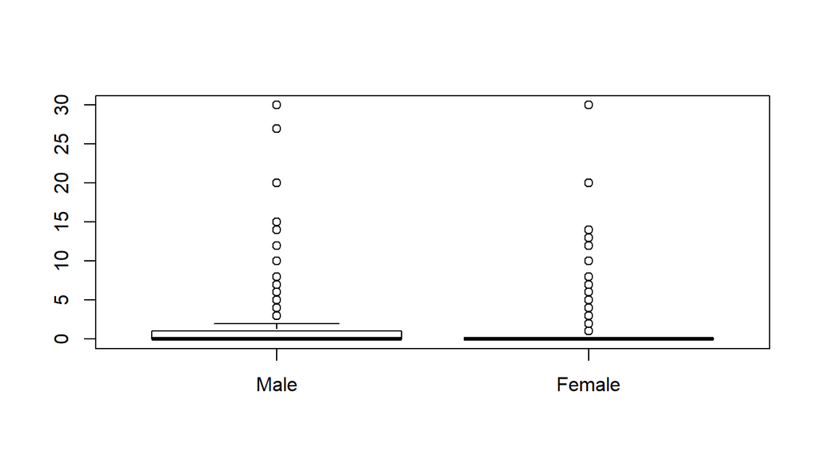

```r
plot(genrisk_sample$sex,genrisk_sample$drnk3ge5)
```

** The data is again made clearer using a table above. Also again, 15 days was used as a cutoff point due to the significantly right skewed nature of the data.**

**The boxplots above show that men tend to binge drink more displaying a higher mean and IQR**

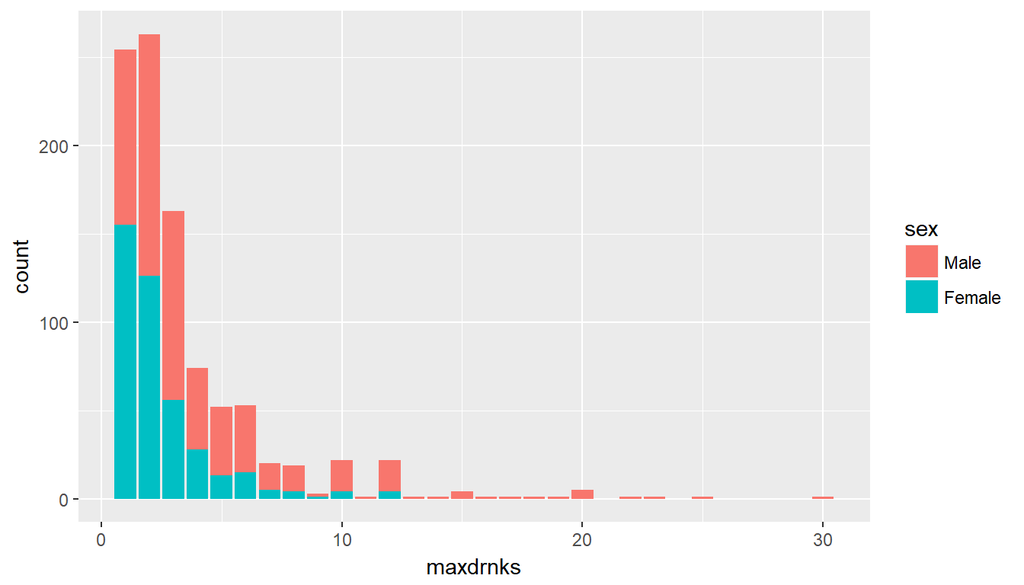

```r
ggplot(data=genrisk_sample,aes(x=maxdrnks,fill=sex))+geom_bar()
```

```r
genrisk_sample %>%
  group_by(maxdrnks,sex) %>%
  filter(maxdrnks<35) %>%
  summarise(count=n())
```

```
## # A tibble: 35 x 3
## # Groups:   maxdrnks [?]
##    maxdrnks    sex count
##       <int> <fctr> <int>
##  1        1   Male    99
##  2        1 Female   155
##  3        2   Male   137
##  4        2 Female   126
##  5        3   Male   107
##  6        3 Female    56
##  7        4   Male    46
##  8        4 Female    28
##  9        5   Male    39
## 10        5 Female    13
## # ... with 25 more rows
```

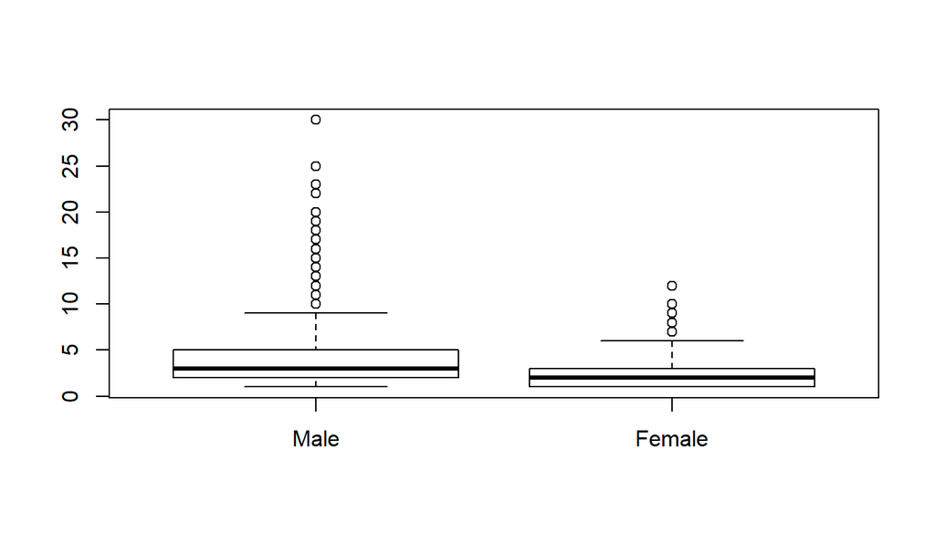

```r
plot(genrisk_sample$sex,genrisk_sample$maxdrnks)
```

**When it comes to maximum number of drinks on a single occasion, women tend to have just one drink 56 more times. Although, similar to the previous alcohol consumption data, the numbers increase for men as compared to women as the number of drinks increases.** **The table above details the data while the boxplot further reflects the bar chart.** ** **

**Conclusion: In general the numbers tend to support the claim that men tend to engage in tobacco use and alcohol consumption more often than women. The data is comparable when it comes to smoking but inclines towards men when it comes to smokeless tobacco products. When it comes to alcohol consumption, the results are comparable when moderate alcohol consumption is taken into account. Although men start to show significantly higher drinking habits when the frequency of drinking or the amount of drinks increases.**

**Generalizability: This analysis could be generalized to the entire men and women population since stratified sampling was used to pick 1000 random samples were selected for men and women.**

**Causality: Claims about causality cannot be made since this is an observational study and not an experimental one. As a result, there is no random assignment as well.**

**Sources of bias: Non-response bias could be a factor as we simply chose to ignore the ‘N/A’ responses in many cases. Those could have changed the results. Although, assuming that non-responses were equally distributed among men and women, they might not affect the data in the end. Voluntary bias could be a factor as only people with health concerns or risk behaviors may have decided to participate in the survey.**

**Research quesion 2: Among people who are employed, how are education and income level related to their health?**

**The dataset chosen for this question is everyone in the population who are employed.**

**Filtering the brfss2013 dataset for the variables of interest and modifying the employment status variable to include only people who are either employed for wages or self-employed** ** **

```r
inedhlth <- brfss2013 %>%
  select(employ1,educa,income2,genhlth,menthlth,physhlth,poorhlth) %>%
filter(employ1=="Employed for wages" | employ1=="Self-employed")
```

**Looking at the distribution of education levels** ** **

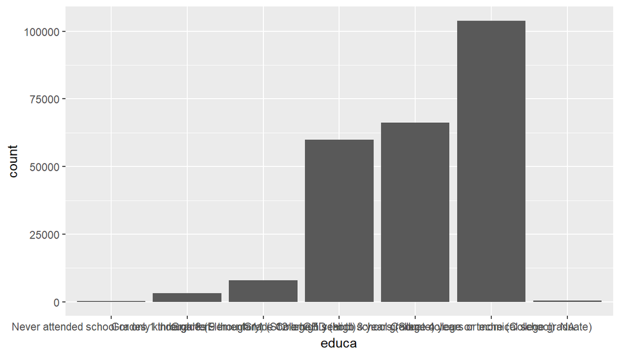

```r
ggplot(data=inedhlth,aes(x=educa)) + geom_bar()
```

```r
inedhlth %>%
  group_by(educa) %>%
  summarise(count=n())
```

```
## # A tibble: 7 x 2
##                                                          educa  count
##                                                         <fctr>  <int>
## 1                   Never attended school or only kindergarten    247
## 2                              Grades 1 through 8 (Elementary)   3211
## 3                        Grades 9 though 11 (Some high school)   7973
## 4                       Grade 12 or GED (High school graduate)  59882
## 5 College 1 year to 3 years (Some college or technical school)  66270
## 6                   College 4 years or more (College graduate) 103946
## 7                                                         <NA>    503
```

**The plot above shows a left skewed distribution. It appears from the education data that a large portion of the sample population consists of college graduates. The second most prevalent level is some sort of college experience and the next highest is a high school graduate. Therefore, it is clear that most of the population has at least graduated high school.**

**The table further clarifies the numbers. Please refer to the table if the axes values are not clear from the plot.**

**Looking at the distribution of income levels**

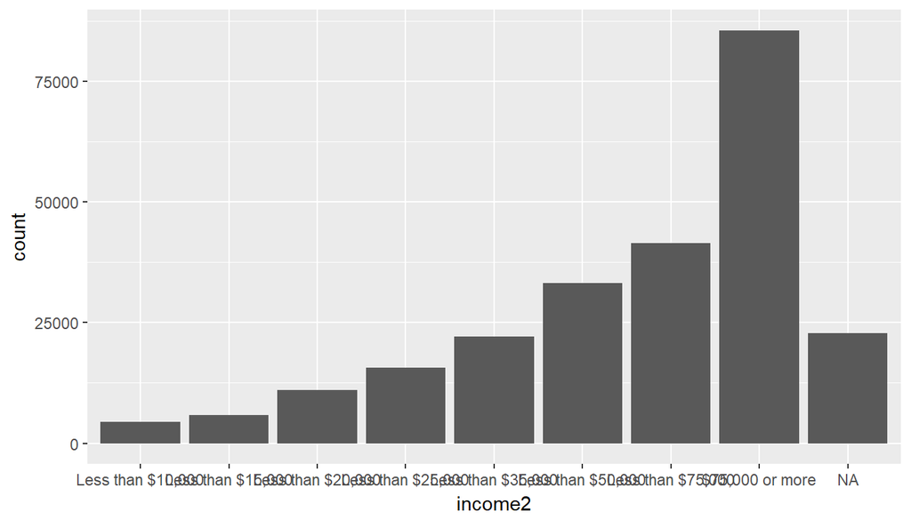

```r
ggplot(data=inedhlth,aes(x=income2)) + geom_bar()
```

```r
inedhlth %>%
  group_by(income2) %>%
  filter(!(is.na(income2))) %>%
  summarise(count=n())
```

```
## # A tibble: 8 x 2
##             income2 count
##              <fctr> <int>
## 1 Less than $10,000  4388
## 2 Less than $15,000  5847
## 3 Less than $20,000 11040
## 4 Less than $25,000 15673
## 5 Less than $35,000 22147
## 6 Less than $50,000 33144
## 7 Less than $75,000 41475
## 8   $75,000 or more 85554
```

**The plot above is left skewed with a gradual increase in number of people with income levels with more people earning 75k or more than any other income level.**

**The table above details the income levels further.**

**Looking at the plot below for general health of people, individuals with greater income tend to report better health. People reported having ‘very good’ health the most with ‘good’ health the second highest occurrence. In both these categories, people with an income of 75k or more seem to be the highest contingency. Same is the case for ‘excellent health’. As we enter the ‘fair’ and ‘poor’ categories, people with 75k or more income reduce.**

**The mosaic plot below makes the data clearer by showing that people with higher salaries tend to enjoy better health.**

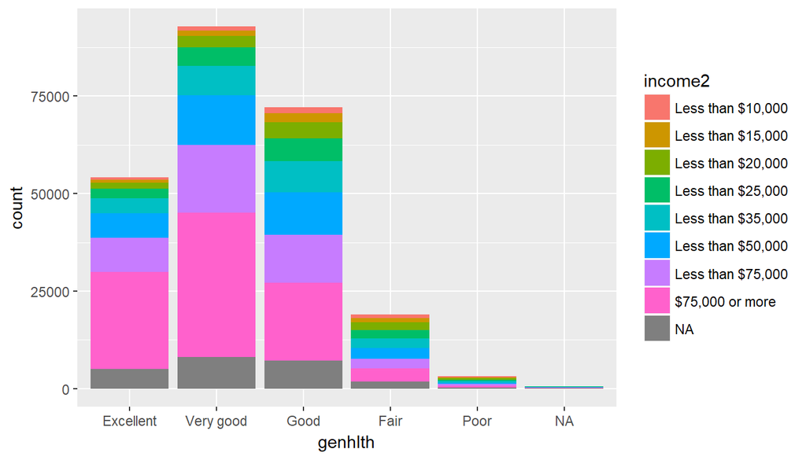

```r
ggplot(data=inedhlth,aes(x=genhlth,fill=income2))+geom_bar()
```

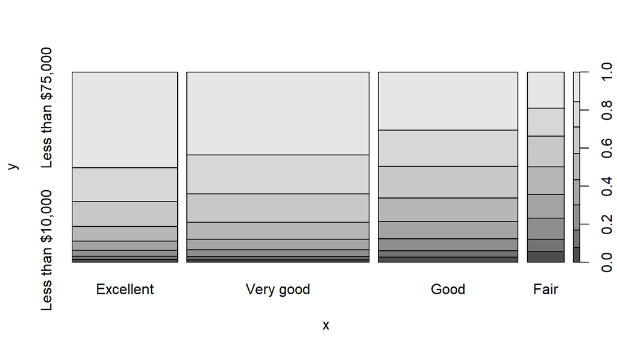

```r
plot(inedhlth$genhlth,inedhlth$income2)
```

**The plot below shows the number of days an individual felt they had bad physical health during a month. As evident from the bar graph, a large majority of people did not have any physical issues, out of which people with 75k or more income had the highest occurrence.**

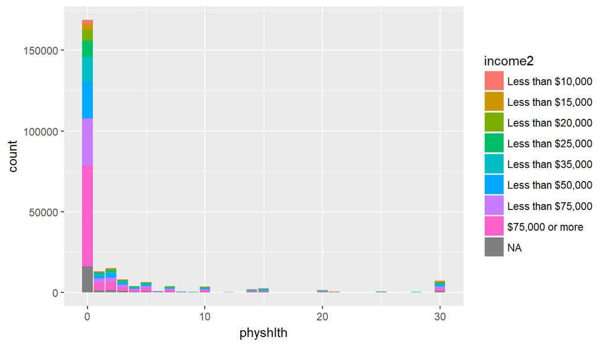

```r
ggplot(data=inedhlth,aes(x=physhlth,fill=income2))+geom_bar()
```

```r
inedhlth %>%
  group_by(income2) %>%
  filter(!(is.na(physhlth))) %>%
  summarise(n(),mean=mean(physhlth),Std_dev = sd(physhlth), Max=max(physhlth),Min=min(physhlth))
```

```
## # A tibble: 9 x 6
##             income2 `n()`     mean  Std_dev   Max   Min
##              <fctr> <int>    <dbl>    <dbl> <dbl> <dbl>
## 1 Less than $10,000  4253 4.705620 8.855262    30     0
## 2 Less than $15,000  5734 4.286885 8.341786    30     0
## 3 Less than $20,000 10829 3.653708 7.718696    30     0
## 4 Less than $25,000 15433 3.044969 7.016167    30     0
## 5 Less than $35,000 21875 2.704091 6.653026    30     0
## 6 Less than $50,000 32814 2.332358 6.139981    30     0
## 7 Less than $75,000 41217 2.115777 5.750539    30     0
## 8   $75,000 or more 85113 1.656739 4.997226    30     0
## 9              <NA> 22212 2.267828 6.191596    30     0
```

**A better understanding of the data is provided by the table above which displays the average for each income level. The means show a gradual increase with decreasing income. Despite not being a dramatic difference, this piece of data tells us that on average, people with higher income experience less number of days with poor physical health.**

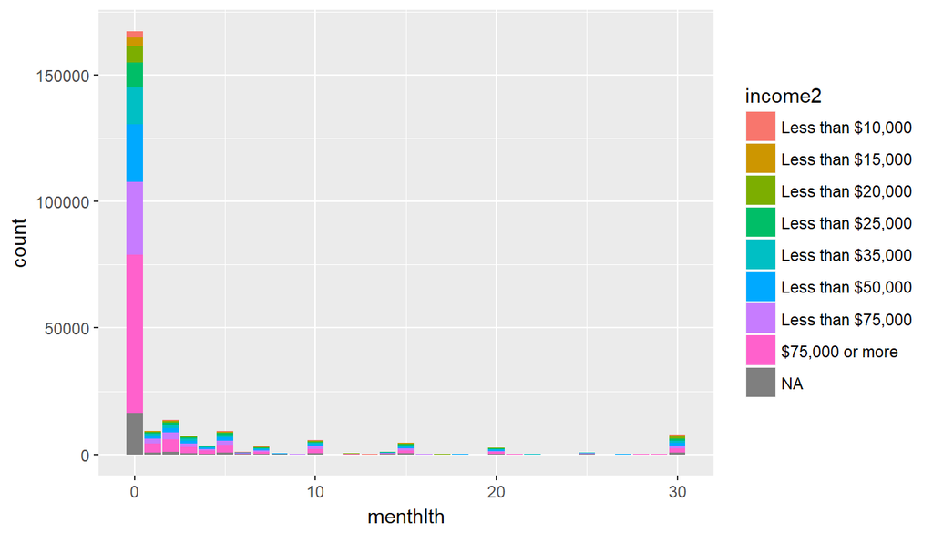

```r
ggplot(data=inedhlth,aes(x=menthlth,fill=income2))+geom_bar()
```

```r
inedhlth %>%
  group_by(income2) %>%
  filter(!(is.na(menthlth))) %>%
  summarise(n(),mean=mean(menthlth),Std_dev = sd(menthlth), Max=max(menthlth),Min=min(menthlth))
```

```
## # A tibble: 9 x 6
##             income2 `n()`     mean  Std_dev   Max   Min
##              <fctr> <int>    <dbl>    <dbl> <dbl> <dbl>
## 1 Less than $10,000  4282 5.412191 9.438517    30     0
## 2 Less than $15,000  5742 5.151167 9.096540    30     0
## 3 Less than $20,000 10839 4.279915 8.324681    30     0
## 4 Less than $25,000 15475 3.779321 7.869350    30     0
## 5 Less than $35,000 21875 3.283657 7.342690    30     0
## 6 Less than $50,000 32856 2.790693 6.663368    30     0
## 7 Less than $75,000 41204 2.406053 6.039719    30     0
## 8   $75,000 or more 85019 1.865454 5.214889    30     0
## 9              <NA> 22226 2.447629 6.481308    30     0
```

**Similar to physical health, mental health statistics show an increase in number of days of poor health with decreasing income level.**

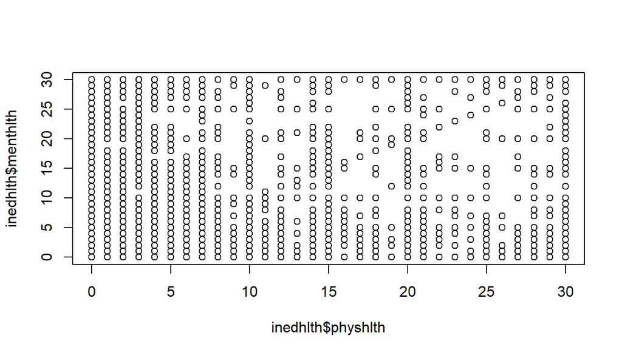

```r
plot(inedhlth$physhlth,inedhlth$menthlth)
```

**Just to see if there is any correlation between physical and mental health, the plot above was made. The data does not suggest any correlation. Therefore the two conditions can be evaluated independently.**

**Education and health analysis**

**The bar chart below shows that college graduates are the highest occurrences in the “excellent” and “very good” general health categories. The education levels start to become comparable at the “good” health category.**

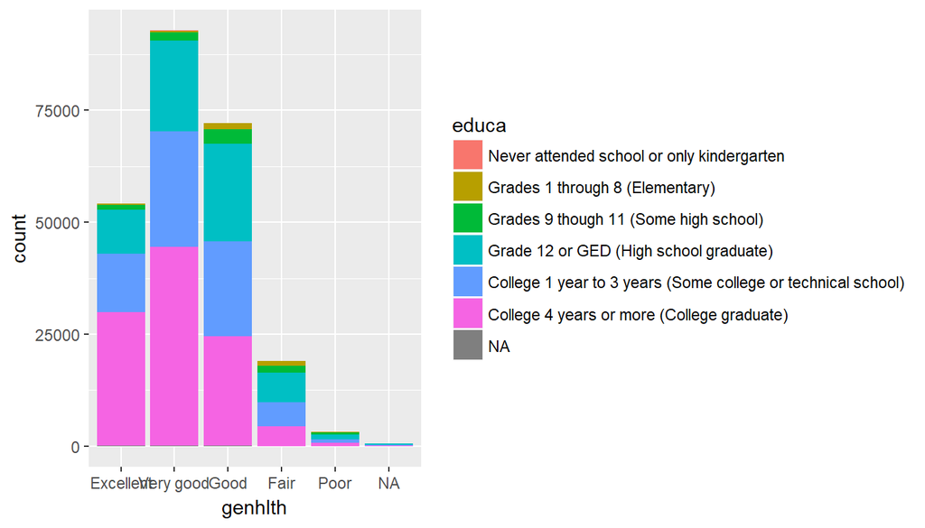

```r
ggplot(data=inedhlth,aes(x=genhlth,fill=educa))+geom_bar()
```

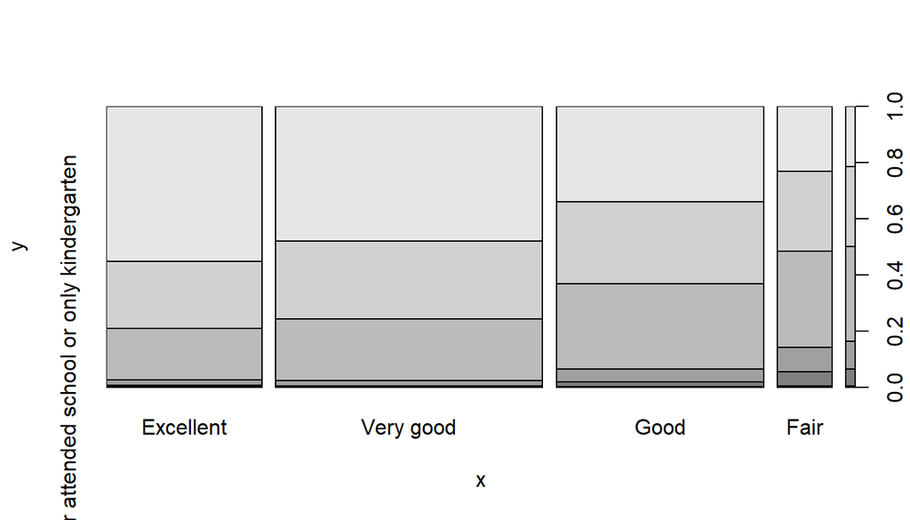

```r
plot(inedhlth$genhlth,inedhlth$educa)
```

**The mosaic plot above makes the data clearer with “excellent” health section exhibits college graduates as the predominant education level.While 1-3 years of college and high school graduate categories show a decent representation in the “excellent”, “very good” and “good” categories, grades lower than 12 have significantly lesser occurrences, but start to increase in the “fair” and “poor” categories.**

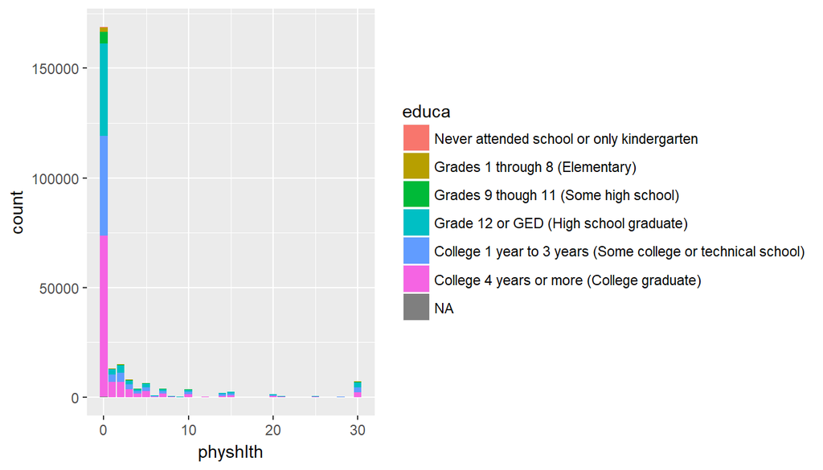

```r
ggplot(data=inedhlth,aes(x=physhlth,fill=educa))+geom_bar()
```

```r
inedhlth %>%
  group_by(educa) %>%
  filter(!(is.na(physhlth))) %>%
  summarise(n(),mean=mean(physhlth),Std_dev = sd(physhlth), Max=max(physhlth),Min=min(physhlth))
```

```
## # A tibble: 7 x 6
##                                                          educa  `n()`
##                                                         <fctr>  <int>
## 1                   Never attended school or only kindergarten    230
## 2                              Grades 1 through 8 (Elementary)   3109
## 3                        Grades 9 though 11 (Some high school)   7757
## 4                       Grade 12 or GED (High school graduate)  59032
## 5 College 1 year to 3 years (Some college or technical school)  65626
## 6                   College 4 years or more (College graduate) 103248
## 7                                                         <NA>    478
## # ... with 4 more variables: mean <dbl>, Std_dev <dbl>, Max <dbl>,
## #   Min <dbl>
```

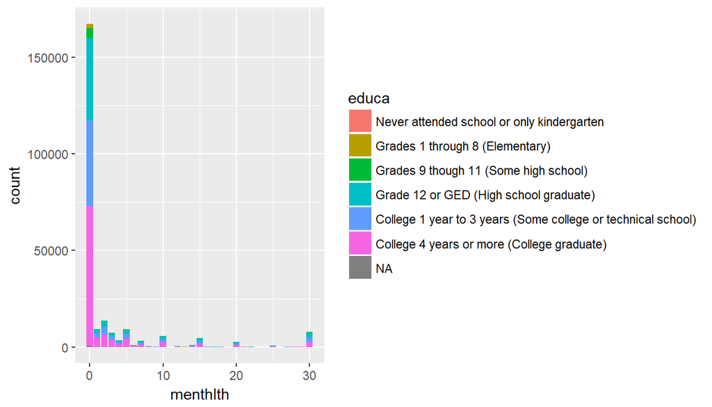

```r
ggplot(data=inedhlth,aes(x=menthlth,fill=educa))+geom_bar()
```

```r
inedhlth %>%
  group_by(educa) %>%
  filter(!(is.na(menthlth))) %>%
  summarise(n(),mean=mean(menthlth),Std_dev = sd(menthlth), Max=max(menthlth),Min=min(menthlth))
```

```
## # A tibble: 7 x 6
##                                                          educa  `n()`
##                                                         <fctr>  <int>
## 1                   Never attended school or only kindergarten    235
## 2                              Grades 1 through 8 (Elementary)   3128
## 3                        Grades 9 though 11 (Some high school)   7809
## 4                       Grade 12 or GED (High school graduate)  59124
## 5 College 1 year to 3 years (Some college or technical school)  65575
## 6                   College 4 years or more (College graduate) 103171
## 7                                                         <NA>    476
## # ... with 4 more variables: mean <dbl>, Std_dev <dbl>, Max <dbl>,
## #   Min <dbl>
```

**The mosaic plot below shows the relationship between education level and income level. As expected, it is clear that college grads tend to have the highest income. The 75k plus income level decreases as the education level is decreased. Therefore, there is a notable correlation between income level and education level.**

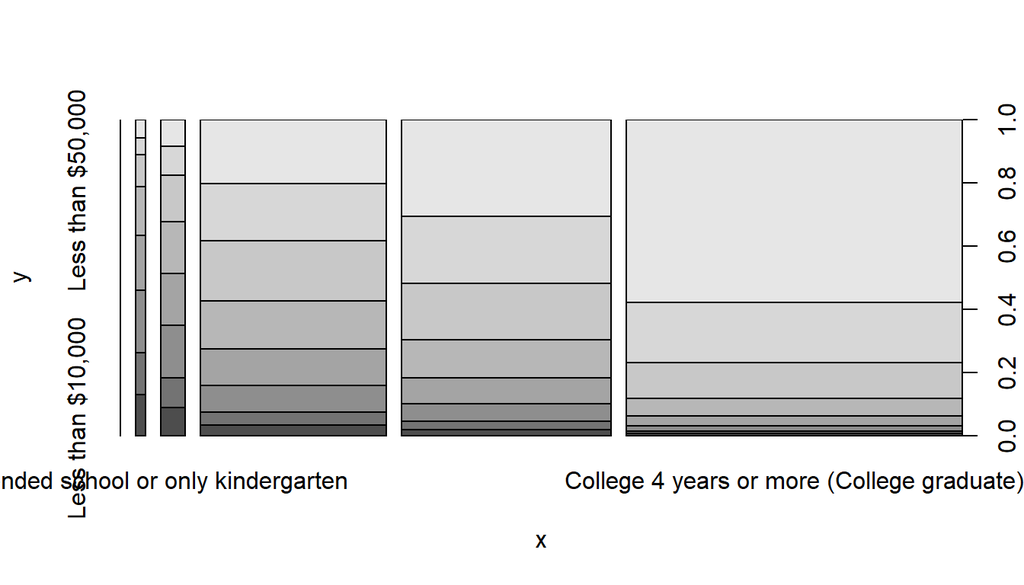

```r
plot(inedhlth$educa,inedhlth$income2)
```

**Conclusion: From the data, there seems to be a correlation between the education level and the income level with higher education level corresponding to greater income. Also, as income levels rise, the reported poor physical and mental health days decrease with 75k plus earners portraying the least general issues. When it comes to education, poor health days decrease with increasing education level but the differences between each education level is not as distinct as the income level categories. Although, graduates clearly have fewer reported poor health days.**

**Generalizability: The results are representative of the entire employed population to a fair extent. The entire employed population was used instead of sampling further. These results don’t take into consideration the distrbution of data among different states or genders.**

**Causality: Cannot prove causality since it is an observational study.**

**Sources of bias: There could be both voluntary bias and non-response bias since there were some non-responses regarding certain variables. Although, since the no responses were not a great amount, it might not affect the outcome of the analysis. There could be voluntary bias involved since people with certain health concerns might look to participate in the survey more than the rest.**

**Research quesion 3: Which states exhibit the highest and lowest rates of chronic diseases?**

**Creating a data subset consisting of the states and 5 of the most prevalent chronic diseases in the US - coronary heart disease, stroke, types of cancer other than skin, kidney disease and diabetes**

```r
chr5 <- brfss2013 %>%
  select(X_state,cvdcrhd4,cvdstrk3,chcocncr,chckidny,diabete3) %>%
  filter(X_state!=0) %>%
  filter(!(is.na(X_state)))
```

**Finding the total responses by state**

```r
statetot <- chr5 %>%
  group_by(X_state) %>%
  filter(X_state!="80") %>%
  summarise(state_count=n()) %>%
  select(X_state,state_count)
```

**Coronary Heart Disease Analysis: The data was filtered further to include only “yes” responses to the disease and a new variable with the rate of the disease per state was created for comparison between states.**

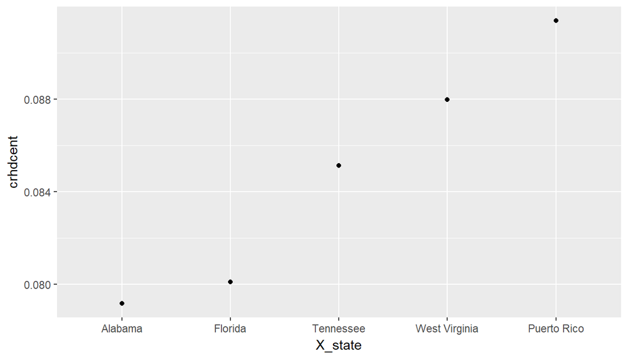

```r
crhd <- chr5 %>%
  group_by(X_state,cvdcrhd4) %>%
  filter(!(is.na(cvdcrhd4))) %>%
  filter(cvdcrhd4=="Yes") %>%
  summarise(count=n()) %>%
  select(X_state,count)
crhd$crhdcent <- (crhd$count)/(statetot$state_count)
crhd <- crhd %>%
  arrange(desc(crhdcent))
ggplot(data=crhd[1:5,],aes(x=X_state,y=crhdcent))+geom_point()
```

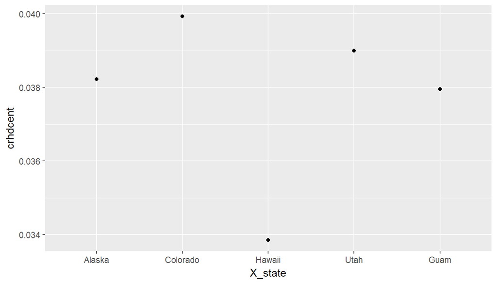

```r
ggplot(data=crhd[(length(crhd$X_state)-4):length(crhd$X_state),],aes(x=X_state,y=crhdcent))+geom_point()
```

**The first of the two plots above shows the top 5 states with the highest rates of diagnosed coronary heart disease - Puerto Rico, West Virginia, Tennessee, Florida and Alabama**

**The second plot shows the 5 states with the lowest rates - Hawaii, Guam, Alaska, Utah and Colorado**

**Stroke Analysis: The data was filtered in a similar way as the above example**

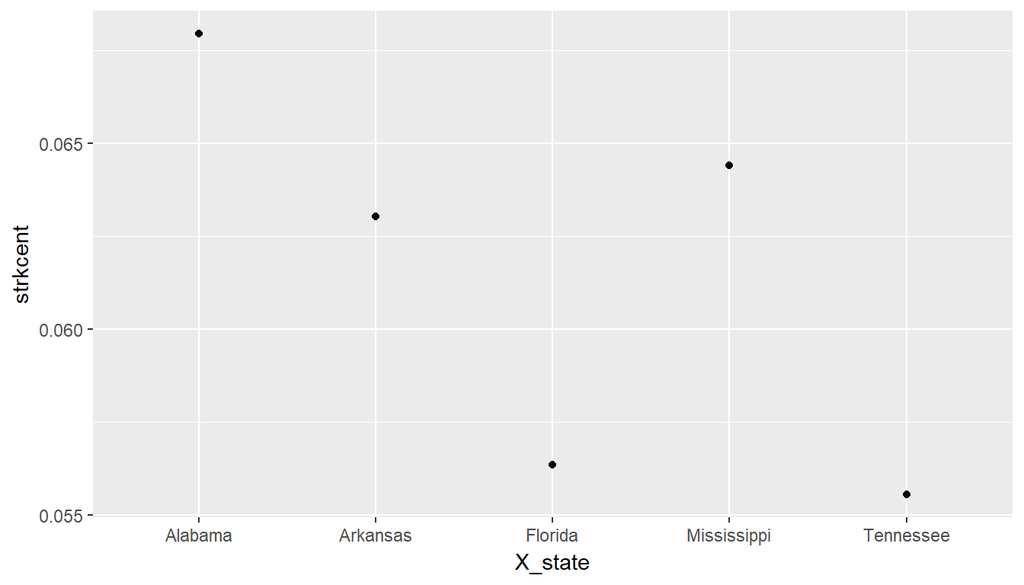

```r
strk <- chr5 %>%
  group_by(X_state,cvdstrk3) %>%
  filter(!(is.na(cvdstrk3))) %>%
  filter(cvdstrk3=="Yes") %>%
  summarise(count=n()) %>%
  select(X_state,count)
strk$strkcent <- (strk$count)/(statetot$state_count)
strk <- strk %>%
  arrange(desc(strkcent))
ggplot(data=strk[1:5,],aes(x=X_state,y=strkcent))+geom_point()
```

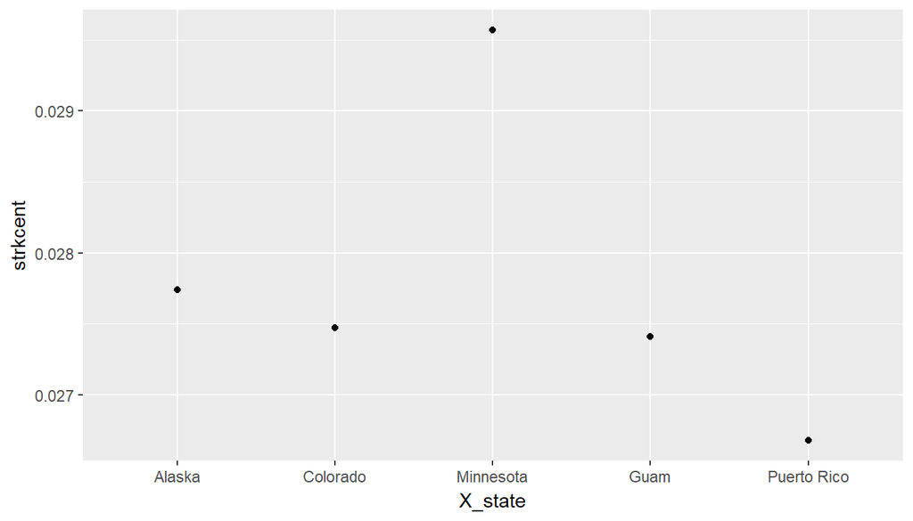

```r
ggplot(data=strk[(length(strk$X_state)-4):length(strk$X_state),],aes(x=X_state,y=strkcent))+geom_point()
```

**Highest rates of strokes exist in Alabama, Mississippi, Arkansas, Florida and Tennessee. The lowest rates exist in Puerto Rico, Guam, Colorado, Alaska and Minnesota**

**Cancer Analysis**

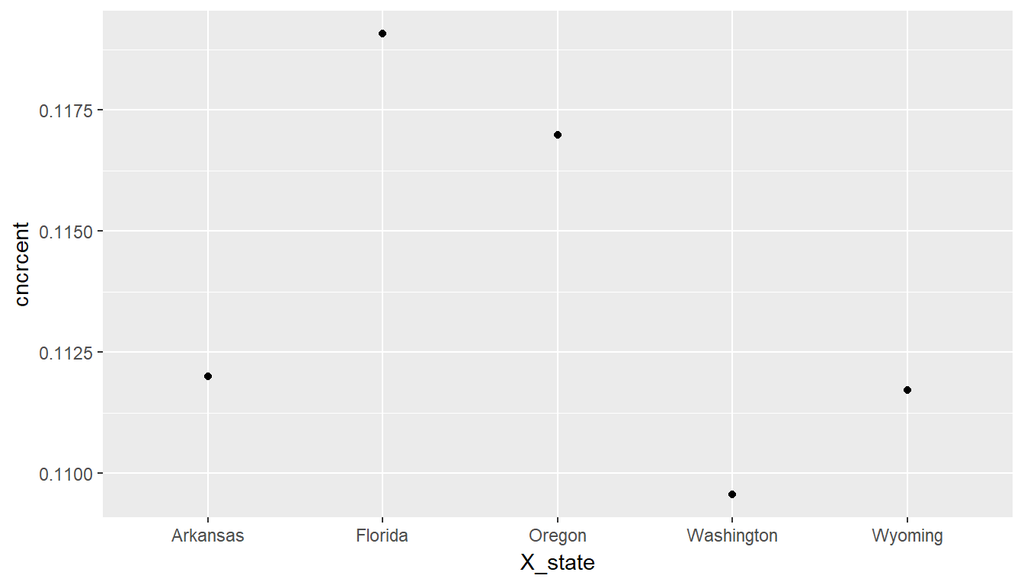

```r
cncr <- chr5 %>%
  group_by(X_state,chcocncr) %>%
  filter(!(is.na(chcocncr))) %>%
  filter(X_state!=0) %>%
  filter(chcocncr=="Yes") %>%
  summarise(count=n()) %>%
  select(X_state,count)
cncr$cncrcent <- (cncr$count)/(statetot$state_count)
cncr <- cncr %>%
  arrange(desc(cncrcent))
ggplot(data=cncr[1:5,],aes(x=X_state,y=cncrcent))+geom_point()
```

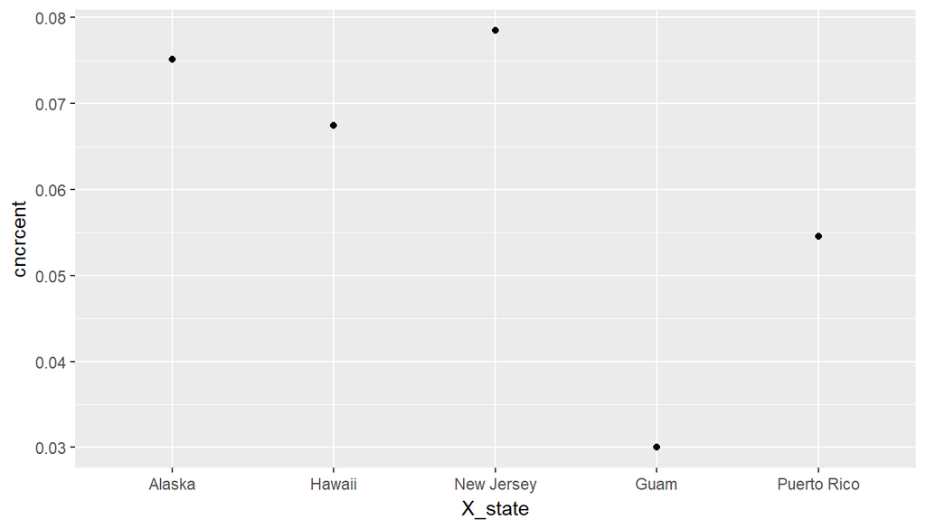

```r
ggplot(data=cncr[(length(cncr$X_state)-4):length(cncr$X_state),],aes(x=X_state,y=cncrcent))+geom_point()
```

**Cancer rates seem to be highest in the following states: Florida, Oregon, Arkansas, Wyoming and Washington. The lowest rates are in Guam, Puerto Rico, Hawaii, Alaska and New Jersey**

**Kidney Disease Analysis**

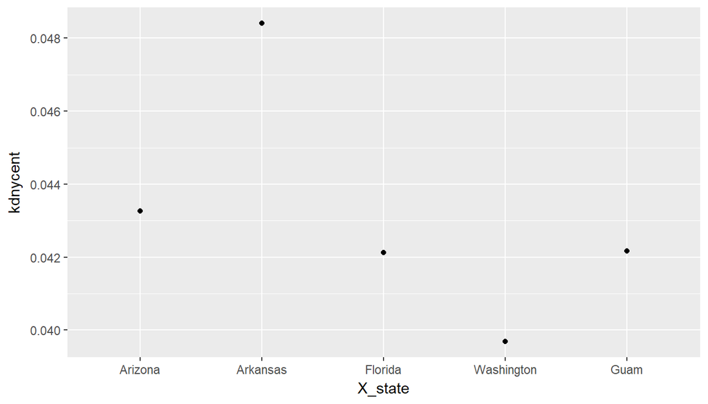

```r
kdny <- chr5 %>%
  group_by(X_state,chckidny) %>%
  filter(!(is.na(chckidny))) %>%
  filter(X_state!=0) %>%
  filter(chckidny=="Yes") %>%
  summarise(count=n()) %>%
  select(X_state,count)
kdny$kdnycent <- (kdny$count)/(statetot$state_count)
kdny <- kdny %>%
  arrange(desc(kdnycent))
ggplot(data=kdny[1:5,],aes(x=X_state,y=kdnycent))+geom_point()
```

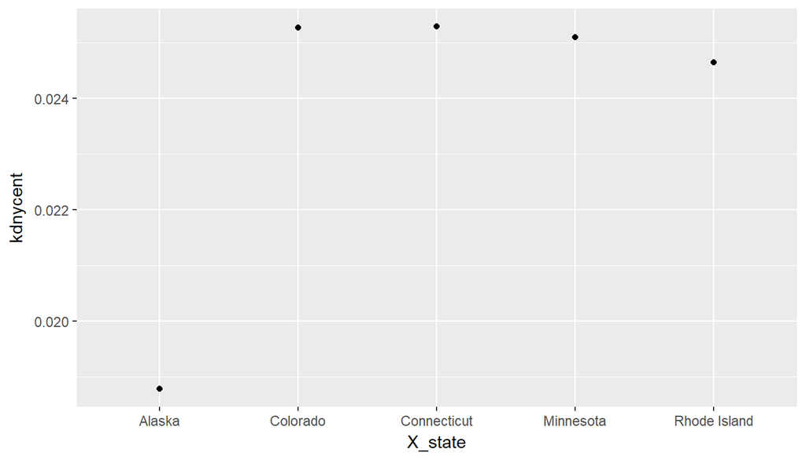

```r
ggplot(data=kdny[(length(kdny$X_state)-4):length(kdny$X_state),],aes(x=X_state,y=kdnycent))+geom_point()
```

**Highest rates of kidney disease are in Arkansas, Arizona, Guam, Florida and Washington. Lowest rates of kidney disease are in Conneticut, Colorado, Minnesota, Rhode Island and Alaska**

**Diabetes Analysis**

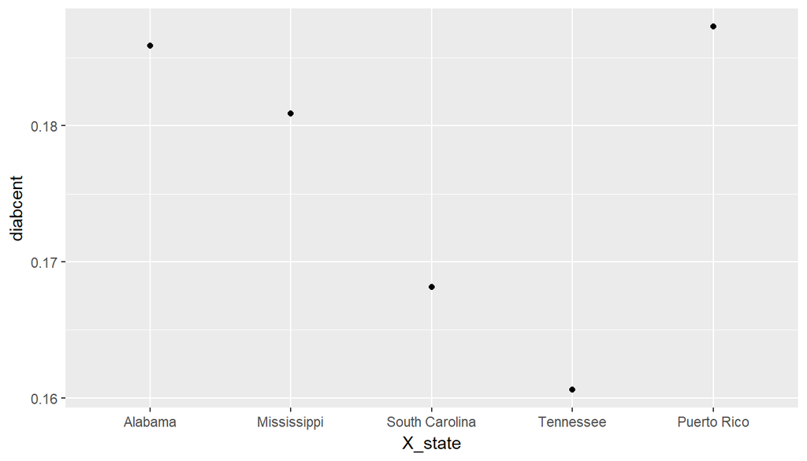

```r
diab <- chr5 %>%
  group_by(X_state,diabete3) %>%
  filter(!(is.na(diabete3))) %>%
  filter(X_state!=0) %>%
  filter(diabete3=="Yes") %>%
  summarise(count=n()) %>%
  select(X_state,count)
diab$diabcent <- (diab$count)/(statetot$state_count)
diab <- diab %>%
  arrange(desc(diabcent))
ggplot(data=diab[1:5,],aes(x=X_state,y=diabcent))+geom_point()
```

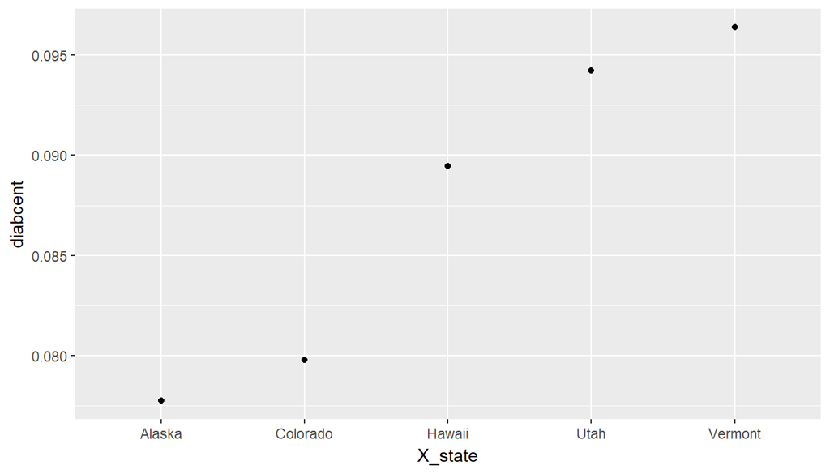

```r
ggplot(data=diab[(length(diab$X_state)-4):length(diab$X_state),],aes(x=X_state,y=diabcent))+geom_point()
```

**The highest rates of diabetes exist in Puerto Rico, Alabama, Mississippi, South Carolina and Tennessee whereas the lowest rates are in Vermont, Utah, Hawaii, Colorado and Alaska.**

**Conclusion: Looking at the data, states/territories such as Guam, Hawaii, Alaska and Colorado seem to exhibit lower rates of chronic diseases overall. The highest rates of chronic diseases seem to occur in states such as Mississippi, Florida, Arkansas, Alabama and Tennessee.**

**Generalizability: Representing the data for each state as a percentage of the total responses makes the results fairly generalizable as some states clearly had a larger number of responses than others. For example, Florida had by far the largest participation.**

**Sources of bias: There could be voluntary bias since people who are specifically concerned with the above diseases might be the ones reporting data. For example, Florida had one of the highest rates of diseases which could be due to their massive survey participation rate. Non-response bias could be a factor as well as people may have chosen not to participate.**